# Clustering Practice

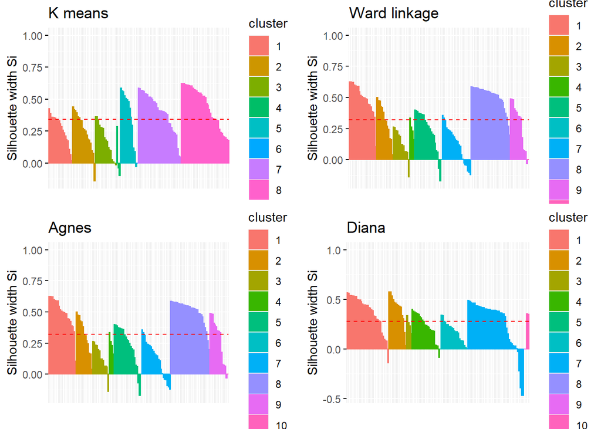

```r
ggarrange(plotlist = plot_list, ncol = 2, nrow = 2)
```

Before we continue with the determination of the best number of clusters and method among the chosen, lets see the dendrograms produced by each hierarchical method:  
*Ward agglomerative*

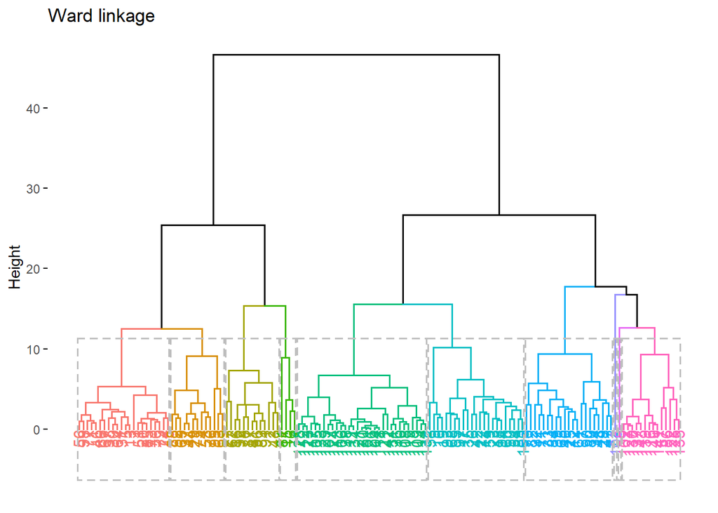

```r
fviz_dend(clust_list[[2]], rect = TRUE,
                             main = names(clust_list)[2])
```

*Agnes*

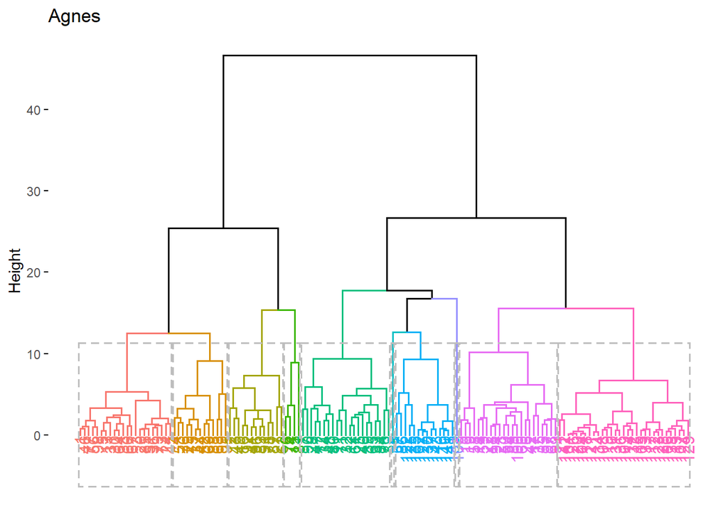

```r
fviz_dend(clust_list[[3]], rect = TRUE,
                             main = names(clust_list)[3])
```

*Diana*

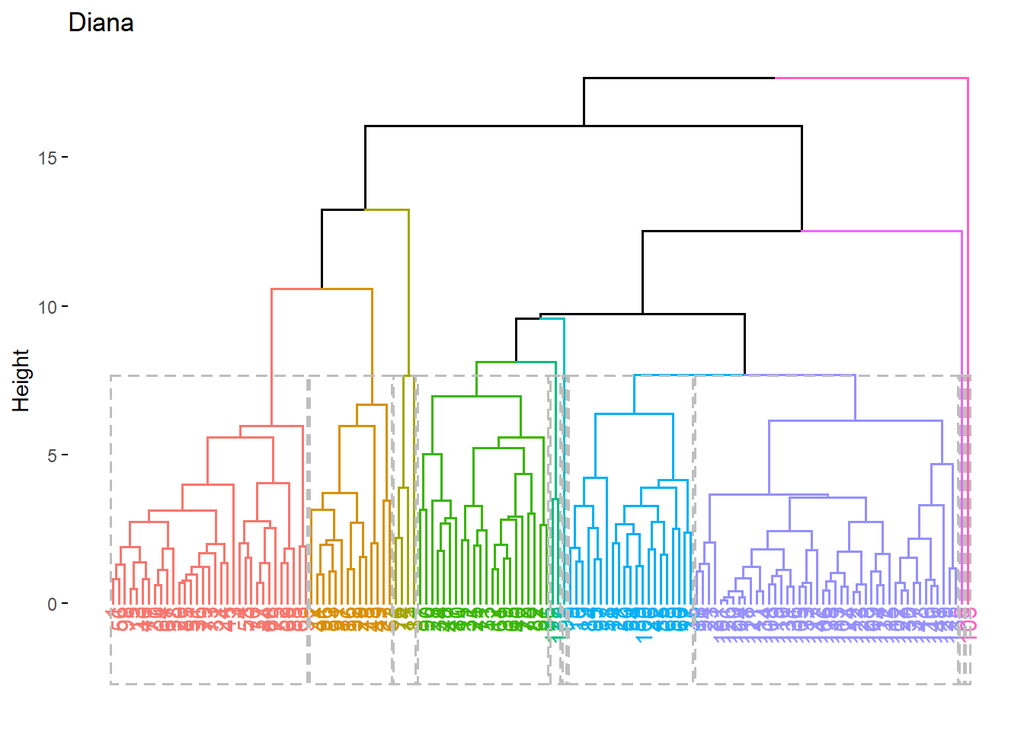

```r
fviz_dend(clust_list[[4]], rect = TRUE,
                             main = names(clust_list)[4])
```

And now, after displaying all the dendrograms, lets analyse the distribution of the number of clusters in k-means and hierarchical methods:

```r
hc.nbclust= NbClust(data = league_df, distance = "euclidean", min.nc = 2, max.nc = 10, method = "ward.D2")
```

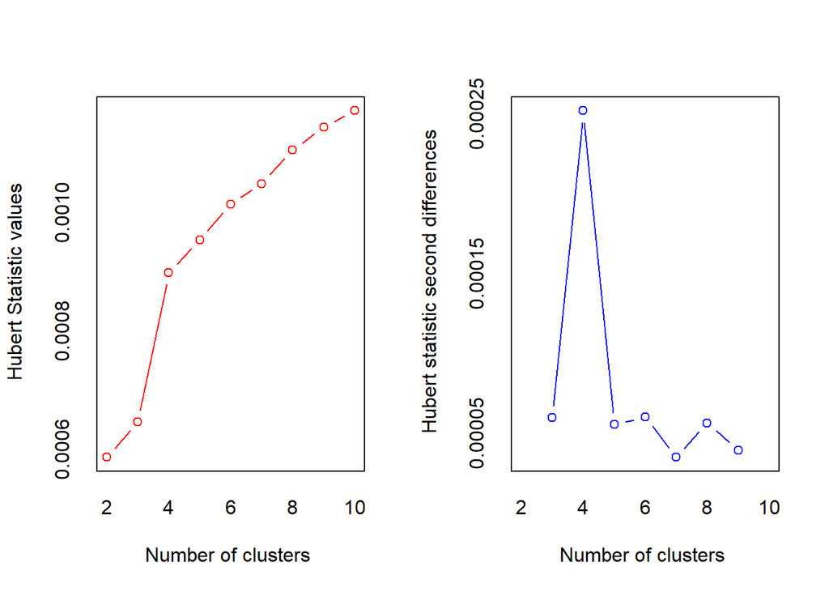

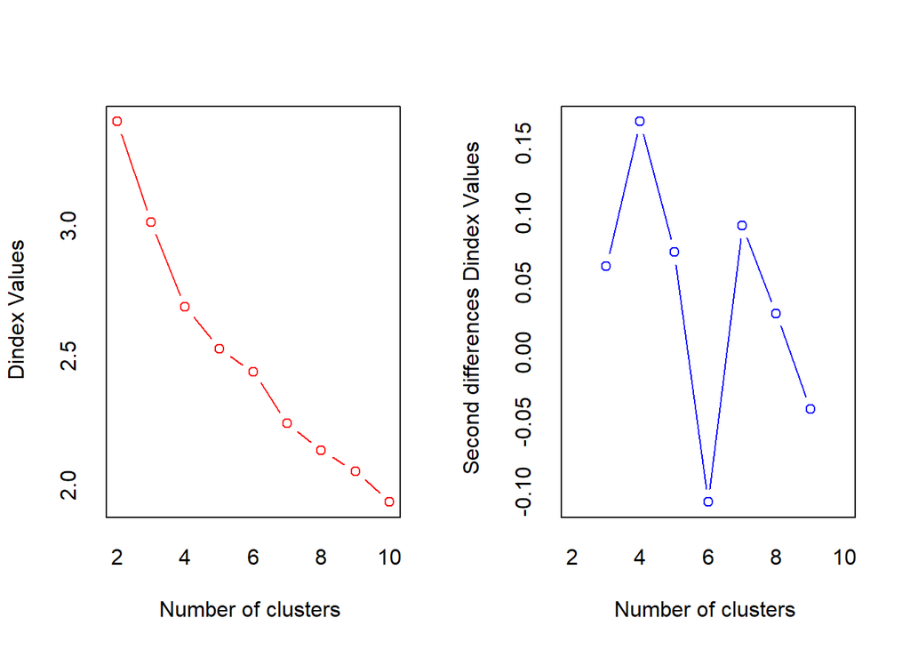

```r
km.nbclust= NbClust(data = league_df, distance = "euclidean", min.nc = 2, max.nc = 10, method = "kmeans")
```

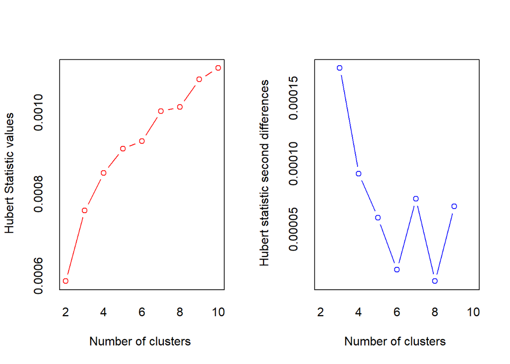

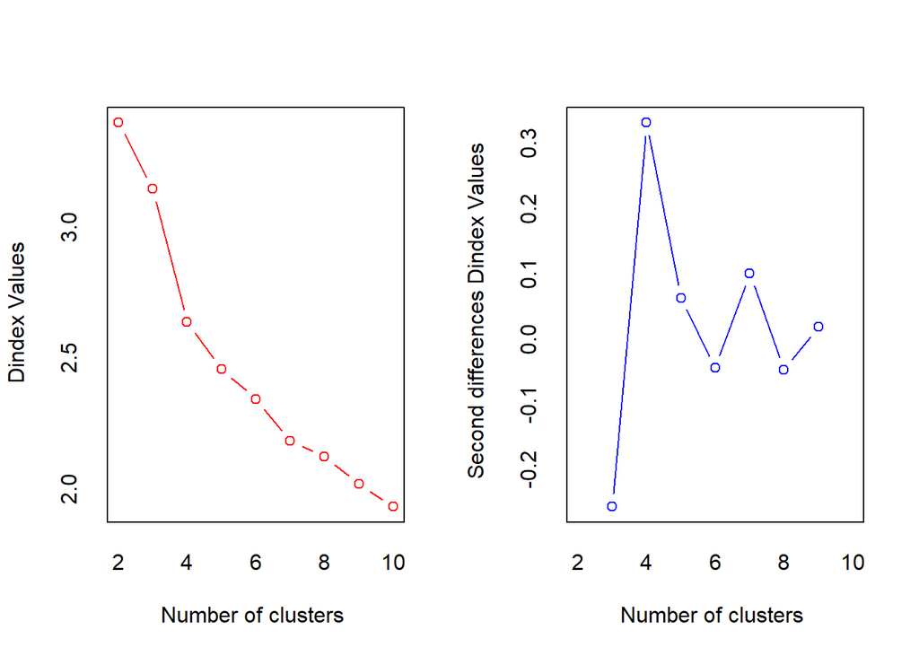

```r
hc.nbgraph = fviz_nbclust(hc.nbclust, ggtheme = theme_minimal()) +
  ylim(0,8)
```

```
## Among all indices:
## ===================
## * 2 proposed  0 as the best number of clusters
## * 1 proposed  1 as the best number of clusters
## * 5 proposed  2 as the best number of clusters
## * 2 proposed  3 as the best number of clusters
## * 4 proposed  4 as the best number of clusters
## * 4 proposed  5 as the best number of clusters
## * 3 proposed  6 as the best number of clusters
## * 3 proposed  9 as the best number of clusters
## * 2 proposed  10 as the best number of clusters
##
## Conclusion
## =========================
## * According to the majority rule, the best number of clusters is  2 .
```

```r
km.nbgraph = fviz_nbclust(km.nbclust, ggtheme = theme_minimal()) +
  ylim(0,8)
```

```
## Among all indices:
## ===================
## * 2 proposed  0 as the best number of clusters
## * 11 proposed  2 as the best number of clusters
## * 1 proposed  3 as the best number of clusters
## * 7 proposed  4 as the best number of clusters
## * 1 proposed  7 as the best number of clusters
## * 1 proposed  9 as the best number of clusters
## * 3 proposed  10 as the best number of clusters
##
## Conclusion
## =========================
## * According to the majority rule, the best number of clusters is  2 .
```

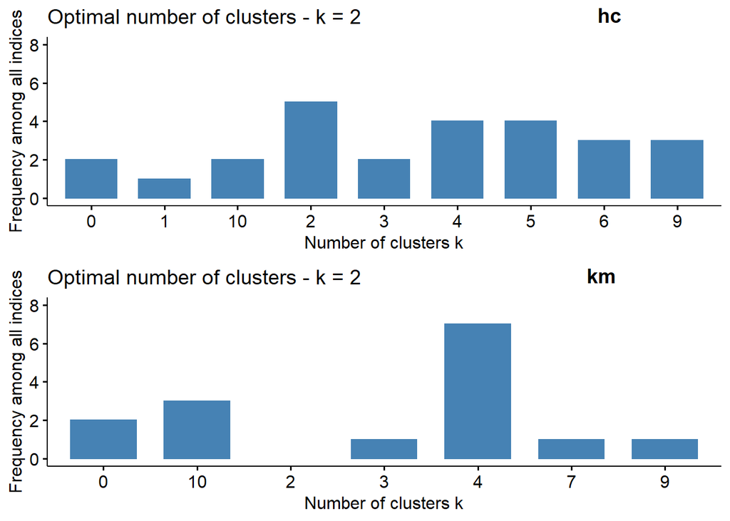

```r
ggarrange(hc.nbgraph, km.nbgraph, nrow = 2, labels = c("hc", "km"),
          hjust = c(-25, -20))
```

And now, using stability and internal measures for clusterin validation, we will assess all methods and choose the best in each measure.  
*Stability measures*

```r
cl_methods = c("hierarchical", "agnes" , "diana", "kmeans")
n = 2:10
better_stability = clValid(as.matrix(league_df), n, cl_methods,
                           validation ="stability",
                           metric = "euclidean", method = "ward")
optim.stab = optimalScores(better_stability)

# copying the code above

# trying to plot using ggplot
# first converting the data to data frame
str(better_stability)
measures = better_stability@measures
```

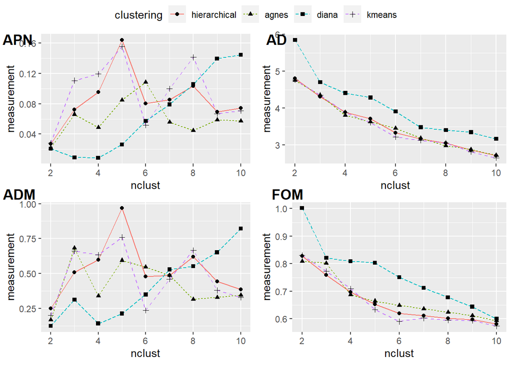

```r
for (i in 1:length(cl_methods)){
  local_measure = measures[, , cl_methods[i]]
  names.row = rownames(local_measure)
  names.col = colnames(local_measure)
  for (j in 1:nrow(local_measure)){
  rep.clustering = rep(cl_methods[i], ncol(local_measure))
  rep.row = rep(names.row[j],ncol(local_measure))
  row = local_measure[j, 1:length(n)]
  col.names = as.integer(names(row))
  if (j == 1 && i == 1){
  stab.data = data.frame("clustering" = rep.clustering,
                    "type" = rep.row,
                    "nclust" = col.names,
                    "measurement" = row)
  }
  else{
    new_data = data.frame("clustering" = rep.clustering,
                    "type" = rep.row,
                    "nclust" = col.names,
                    "measurement" = row)
    stab.data = bind_rows(stab.data, new_data)
  }
  }
}

plot1 <- stab.data %>%
  filter( type == "APN") %>%
  ggplot( aes(x = nclust, y  = measurement, group = clustering)) +
  geom_line(aes(linetype = clustering, color = clustering)) +
  geom_point(aes(shape = clustering))

plot2 <- stab.data %>%
  filter( type == "AD") %>%
  ggplot( aes(x = nclust, y  = measurement, group = clustering)) +
  geom_line(aes(linetype = clustering, color = clustering)) +
  geom_point(aes(shape = clustering))

plot3 <- stab.data %>%
  filter( type == "ADM") %>%
  ggplot( aes(x = nclust, y  = measurement, group = clustering)) +
  geom_line(aes(linetype = clustering, color = clustering)) +
  geom_point(aes(shape = clustering))

plot4 <- stab.data %>%
  filter( type == "FOM") %>%
  ggplot( aes(x = nclust, y  = measurement, group = clustering)) +
  geom_line(aes(linetype = clustering, color = clustering)) +
  geom_point(aes(shape = clustering))


ggarrange(plot1, plot2, plot3, plot4, labels = c("APN", "AD", "ADM", "FOM"),
          ncol = 2, nrow = 2, hjust = c(-0.1, -0.5, -0.1, -0.5),
          vjust = c(1.5, 1.5, 0.25, 0.25), common.legend = TRUE)
```

```r
print(optim.stab)
```

```
##           Score Method Clusters
## APN 0.008794248  diana        4
## AD  2.654557430 kmeans       10
## ADM 0.123891567  diana        2
## FOM 0.574144712 kmeans       10
```

*internal measures*

```r
better_internal_measures = clValid(as.matrix(league_df), n, cl_methods,validation = "internal" ,metric = "euclidean", method = "ward")
optim.intern = optimalScores(better_internal_measures)
str(better_internal_measures)
measures = better_internal_measures@measures
```

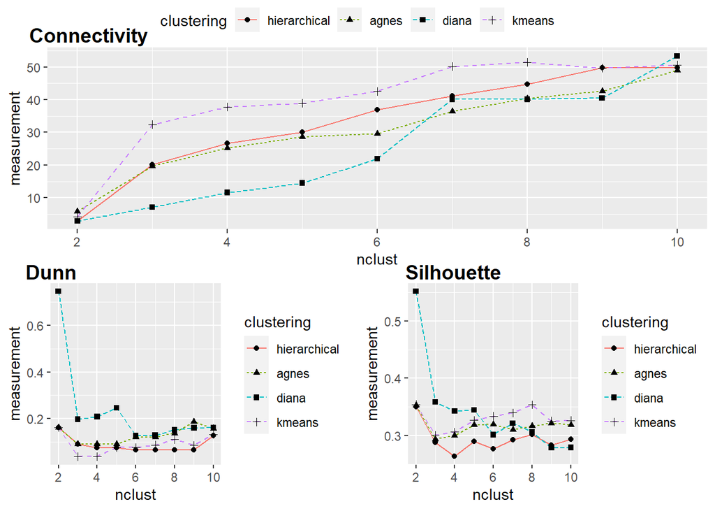

```r
for (i in 1:length(cl_methods)){
  local_measure = measures[, , cl_methods[i]]
  names.row = rownames(local_measure)
  names.col = colnames(local_measure)
  for (j in 1:nrow(local_measure)){
  rep.clustering = rep(cl_methods[i], ncol(local_measure))
  rep.row = rep(names.row[j],ncol(local_measure))
  row = local_measure[j, 1:length(n)]
  col.names = as.integer(names(row))
  if (j == 1 && i == 1){
  intern.data = data.frame("clustering" = rep.clustering,
                    "type" = rep.row,
                    "nclust" = col.names,
                    "measurement" = row)
  }
  else{
    new_data = data.frame("clustering" = rep.clustering,
                    "type" = rep.row,
                    "nclust" = col.names,
                    "measurement" = row)
    intern.data = bind_rows(intern.data, new_data)
  }
  }
}

plot1 <- intern.data %>%
  filter( type == "Connectivity") %>%
  ggplot( aes(x = nclust, y  = measurement, group = clustering)) +
  geom_line(aes(linetype = clustering, color = clustering)) +
  geom_point(aes(shape = clustering))

plot2 <- intern.data %>%
  filter( type == "Dunn") %>%
  ggplot( aes(x = nclust, y  = measurement, group = clustering)) +
  geom_line(aes(linetype = clustering, color = clustering)) +
  geom_point(aes(shape = clustering))

plot3 <- intern.data %>%
  filter( type == "Silhouette") %>%
  ggplot( aes(x = nclust, y  = measurement, group = clustering)) +
  geom_line(aes(linetype = clustering, color = clustering)) +
  geom_point(aes(shape = clustering))


ggarrange(plot1,
             ggarrange(plot2, plot3, ncol = 2, labels = c("Dunn", "Silhouette"),
                       vjust = c(0.25, 0.25)),
             nrow = 2, labels = "Connectivity", vjust = 0.15,
          hjust = -0.25, common.legend = TRUE)
```

with the respective optimum statistics:

```r
print(optim.intern)
```

```
##                  Score       Method Clusters
## Connectivity 2.9079365 hierarchical        2
## Dunn         0.7459732        diana        2
## Silhouette   0.5514278        diana        2
```